# ch05_03_02_model_validation(2)_threshold

### 모델 검증

- 임계값에 따른 평가지표 확인

#### 1.1.1 이진 분류의 평가지표

### 1.1.2 임계값과 평가지표

#### 1.1.3 평가지표 - ROC 커브, AUC

#### 1.1.4 다중 분류의 평가지표

### 학습 내용

- 임계값을 조정하는 것에 따라 정밀도와 민감도가 변하는 것을 확인해 본다.

### 이진 분류 예측 - 예측을 0,1로 하는 것이 아니라 확률로 해보기

- 400개(음성), 50개(양성) 으로 이루어진 불균형 데이터
- 사용 함수 : decision_function(), predict_proba()
  - decision_function을 0으로, predict_proba를 0.5의 임계값으로 사용

### 01 데이터 준비하기

```python
import warnings
warnings.filterwarnings(action='ignore')
```

```python
from sklearn.model_selection import train_test_split
from sklearn.svm import SVC
import mglearn
from sklearn.metrics import classification_report
import matplotlib.pyplot as plt
import numpy as np
```

```python
from mglearn.datasets import make_blobs
X, y = make_blobs(n_samples=(400, 50),
                  centers=2,
                  cluster_std=[7.0, 2],         # 클러스터의 표준 편차
                  random_state=42)

print(X.shape, y.shape)

X_train, X_test, y_train, y_test = train_test_split(X, y, random_state=0)
```

```
(450, 2) (450,)
```

### 데이터 시각화

- 400개의 음성 클래스
- 50개의 양성 클래스

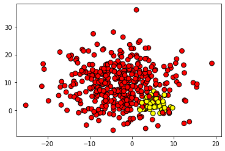

```python
plt.scatter(X[:,0], X[:,1],
            c=y,
            cmap=plt.cm.autumn, s=60, edgecolors='k')
```

### 임계값에 따른 값을 확인

```python
mglearn.plots.plot_decision_threshold()
```

[output not shown]

### 재현율(recall) 조정해보기

- svc.predict()함수로 예측 시. 재현율을 조정하기 어려운 조건.
- decision_function()함수로 예측하여 임계값이 조정이 가능.

### 모델(SVC) 예측 후, 평가 지표 확인

- 모델 : SVC
- 정밀도, 민감도, f1-score 확인

```python
svc = SVC(gamma=.05).fit(X_train, y_train)
pred = svc.predict(X_test)
print(classification_report(y_test, pred))
```

[output not shown]

### 모델의 임계값을 활용하여 0,1 개수 조정

- 임계값을 0에서 -0.8로 낮추기
- 임계값을 0에서 -0.8로 조정시 양성 클래스(1)의 개수가 늘어난다.

```python
pred = svc.decision_function(X_test)
np.min(pred), np.max(pred)
```

[output not shown]

```python
decision_0 = svc.decision_function(X_test)   > 0     # 임계값을 0으로
decision_m08 = svc.decision_function(X_test) > -.8   # 임계값을 -0.8로

# TP - 잘 맞추는 것을 늘린다.
print("임계값 0 일때    : 1(양성) 개수 :", decision_0.sum() )
print("임계값 -0.8 일때 : 1(양성) 개수 :", decision_m08.sum() )
```

[output not shown]

- 임계값을 변경하여 역으로 1의 개수가 늘고 0의 개수가 줄어든다.

```python
print("임계값 0 일때    : 0(음성) 개수 :", len(decision_0) - decision_0.sum())
print("임계값 -0.8 일때 : 0(음성) 개수 :", len(decision_m08) - decision_m08.sum() )
```

[output not shown]

```python
y_pred_0 = svc.decision_function(X_test)   > 0
y_pred_08 = svc.decision_function(X_test) > -.8
```

```python
# 임계값 0
print(classification_report(y_test, y_pred_0))
```

[output not shown]

```python
print(classification_report(y_test, y_pred_08))
```

[output not shown]

### Review

- 정밀도(precision)
  - TP/(TP + NP) : **예측 양성 전체 중**에 정확하게 잘 맞추었을까?
- 재현율(recall) :
  - TP/(TP + FN) : 실제 양성 데이터의 얼마나 잘 맞추었을까?
  - 다른 말로 **민감도(sensitivity), 적중률(hit rate), 진짜 양성 비율(TPR)**이라고 합니다.
- F1-score \begin{equation} \text{F} = 2 * \frac{\text{정밀도*재현율}}{ \text{정밀도 + 재현율 } } \end{equation}

### 실습

- 임계값을 0보다 큰 값으로 조정해 보고 재현율(recall)를 확인해 보기
- 임계값을 0으로 하고 재현율(recall)과 기타 평가지표를 확인해 보기

### 기타 방법

- predict_proba()메서드는 출력이 0에서 1 사이로 고정
  - 보통은 0.5를 임계값-이는 양성과 음성이 50%분류이다.
  - 임계값을 높이는 것은 양성이 분류될 확률이 많이 나올 때, 수행

교육용으로 작성된 것으로 배포 및 복제시에 사전 허가가 필요합니다.  
Copyright 2021 LIM Co. all rights reserved.